# Part1

## IODS-final

Background

Alcohol use continues to be prevalent among youth. To implement preventive measures the sociodemographic, individual and parental factors behind problem behavior should be understood better.

Both studies included the same measures of alcohol consumption and gambling frequency, and comparable measures of variables in the four domains. Multivariate analyses of variance revealed that impulsivity, moral disengagement, and delinquency (adolescent or peer delinquency) predicted alcohol consumption and gambling in both studies, even after controlling for demographic factors. Parental monitoring, cigarette use, and illicit drug use predicted alcohol consumption in both studies, but did not predict gambling once the demographic and individual factors were taken into account.

Objective

To investigate the association between high alcohol consumption and sociodemographic factors using school reports and questionnaires from two Portuguese schools.

**Research question**

Method

A multiple correspondence analysis was used to analyse sociodemographic and high alcohol use. Additionally, descriptive results are presented stratified by gender, student performance group and high alcohol usage.

Results

Conclusion

There is an indication that some sociodemographic factors have joint effects. It is important to confirm the associations using advanced techniques, e.g. by applying theory of planned behavior to study the relations among personal beliefs, atttudes, behavioral intentions and behaviour.

### Introduction

Data including grades, demographic, social and school related features were collected in two Portuguese schools using school reports and questionnaires and stored as two separate datasets regarding performance in distinct subjects, namely Mathematics and Portuguese. The original data of the analysis in this exercise are freely available as a [zip file](https://archive.ics.uci.edu/ml/machine-learning-databases/00320/) with [metadata](https://archive.ics.uci.edu/ml/datasets/Student+Performance).

For the purpose of this particular exercise the datasets were joined and edited according to [this R script](https://github.com/paap0/IODS-final/blob/master/data/create_Fin_alc.R). The variables not used for joining the two data sets were combined by averaging them. Variables were further categorized to decrease the amount of levels. This approach simultanously decreases the amount of information, buton the other hand facilitates interpreation of the results. Instead of using labels for the created categories the exact ranges were used again to help the interpretation. An additional variable *Alcohol_use* was created. A treshold value was either 2 during weekdays or weekend. by categorizing either using a lot during weekdays or weekend taking the average of the sum of alcohol consumption during weekdays and weekends, which was thereafter further modified to yield a logical TRUE or FALSE *high_use* variable. A treshold value for higher than average alcohol consumption was chosen to be more than 2 weekly proportions.Furthermore, the variables were renamed.

#### Structure of the dataset

Data are loaded. The final data set includes 434 respondents and 19 factorial and one quantitative variable. The names of the variables and their explanations are listed below.

```r
dfalc<-read.csv(file="alccatfiso.csv",header=TRUE)
dfalc<-mutate_all(dfalc,as.factor)
dfalc$Final_Grade<-as.numeric(dfalc$Final_Grade)

Label<-as.matrix(colnames(dfalc))

Variable<-c("Gender", "Age categorized",  "Parent's cohabitation status","Mother´s educational status categorized (less than secondary education, secondary education, higher education", "Father´s educational status categorized (less than secondary education, secondary education, higher education", "Mother´s job (teacher, health care, civil services, at home, other)", "Father´s job (teacher, health care, civil services, at home, other)", "Student´s guardian: mother, father, other", "Family educational support", "Willingness to take higher education", "Relationship", "Extra-cullicular activities", "Familial relationships categorized (very bad to bad, average, good to excellent)","Going out with friends categorized (very low or low, average, high or very high)","Health status categorized (very bad to bad, average, good to very good)", "Amount of failed classes: none/more than one)", "Amount of school absences one or less, 2-6hours, more than 6 hours", "Final grade categorized by quartiles", "Final grade", "Alcohol consumption more than two either during the week or at weekends")

Level<-as.matrix(dfalc %>% sapply(levels))

om<- data.frame(Label,Variable,Level)

om$Level[3]<-"A(Alone),T(Together)"
om$Level[19]<-"numeric from 0 to 20"
rownames(om)<-NULL
kable(om, title="Basic elements of the dataset","html") %>%
  kable_styling(bootstrap_options = "striped", full_width = F)
```

| Label | Variable | Level |
| --- | --- | --- |
| Gender | Gender | F, M |
| Agegroup | Age categorized | (0,16], (16,17], (17,Inf] |
| Parents.together | Parent’s cohabitation status | A(Alone),T(Together) |
| Education_M | Mother´s educational status categorized (less than secondary education, secondary education, higher education | (-1,2], (2,3], (3,4] |
| Education_F | Father´s educational status categorized (less than secondary education, secondary education, higher education | (-1,2], (2,3], (3,4] |
| Job_M | Mother´s job (teacher, health care, civil services, at home, other) | at_home, health, other, services, teacher |
| Job_F | Father´s job (teacher, health care, civil services, at home, other) | at_home, health, other, services, teacher |
| Guardian | Student´s guardian: mother, father, other | father, mother, other |
| Familial_support | Family educational support | no, yes |
| Education_pos | Willingness to take higher education | no, yes |
| In_relationship | Relationship | no, yes |
| Activities | Extra-cullicular activities | no, yes |
| Family_relationships | Familial relationships categorized (very bad to bad, average, good to excellent) | (0,2], (2,3], (3,5] |
| Going_out | Going out with friends categorized (very low or low, average, high or very high) | (0,2], (2,3], (3,5] |
| Healthgroup | Health status categorized (very bad to bad, average, good to very good) | (0,2], (2,3], (3,5] |
| Class_failures | Amount of failed classes: none/more than one) | 0, 1 |
| Absencegroup | Amount of school absences one or less, 2-6hours, more than 6 hours | (-Inf,1], (1,6], (6, Inf] |
| Performancegroup | Final grade categorized by quartiles | (-Inf,10], (10,12], (12,14], (14, Inf] |
| Final_Grade | Final grade | numeric from 0 to 20 |
| High_alcohol | Alcohol consumption more than two either during the week or at weekends | 0, 1 |

### Descriptive results

#### Graphical overview

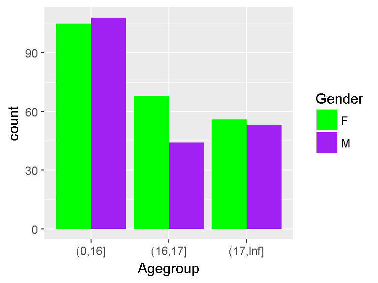

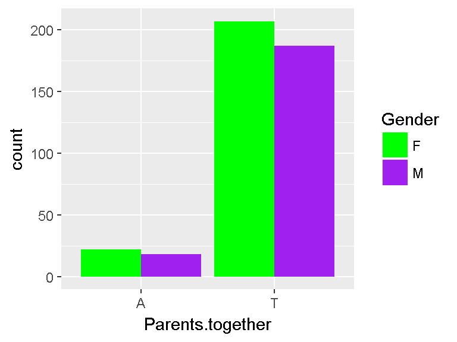

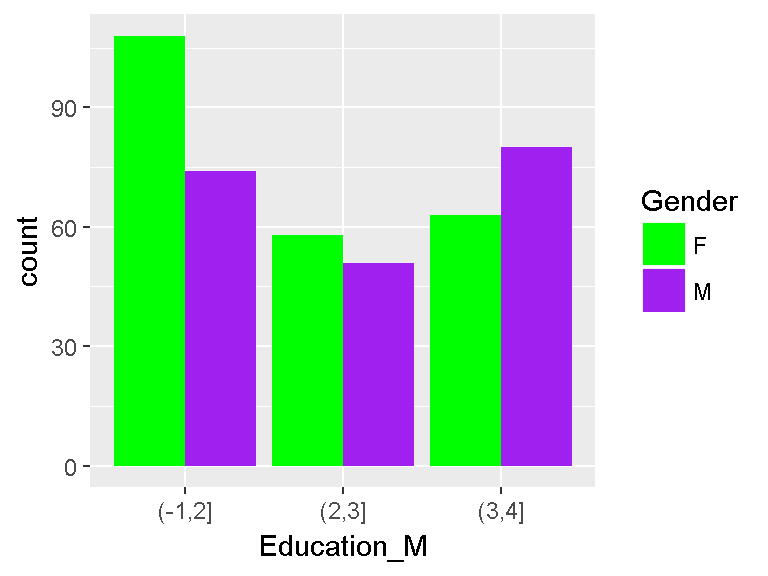

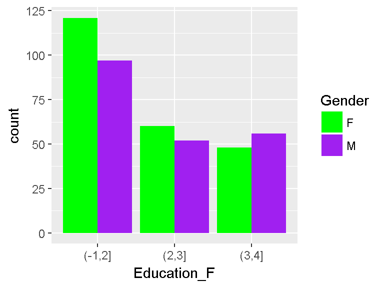

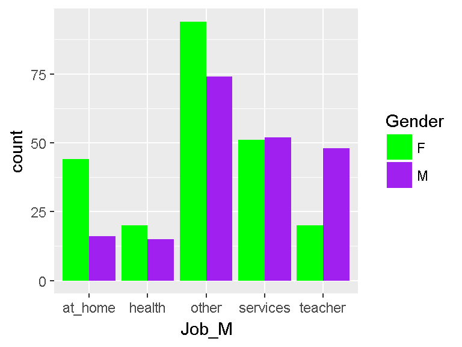

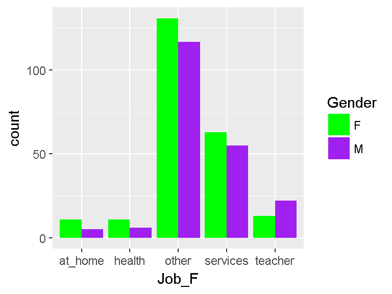

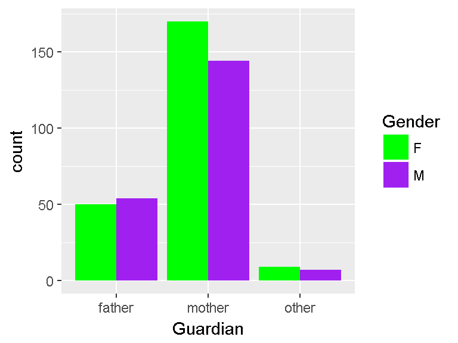

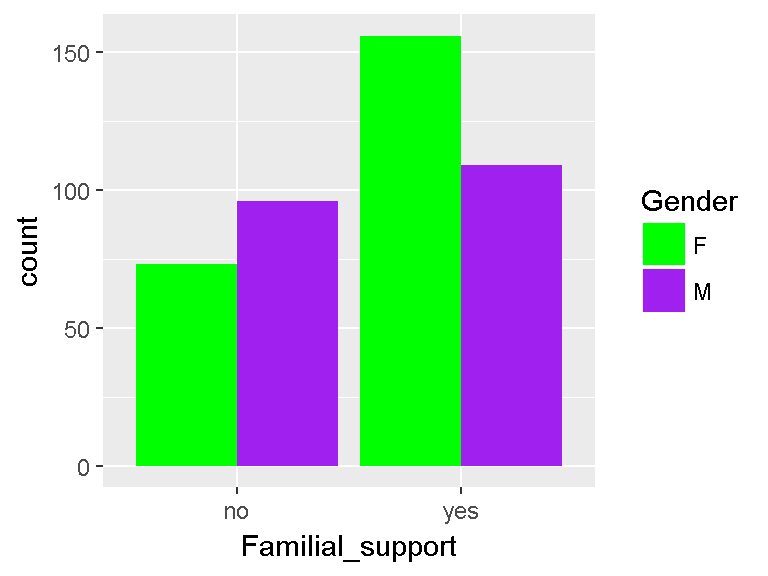

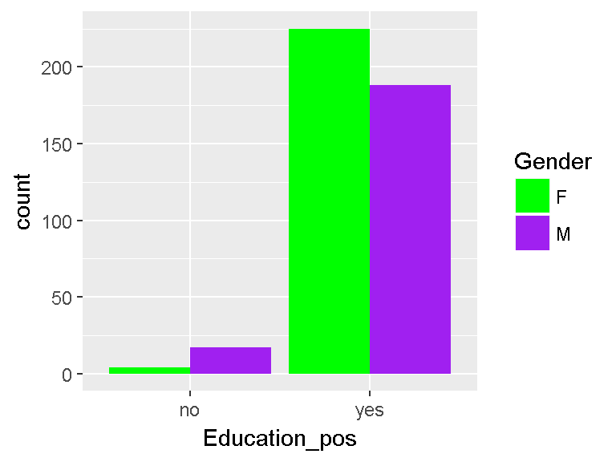

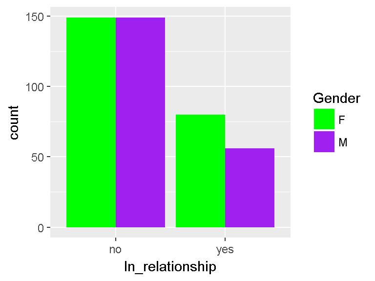

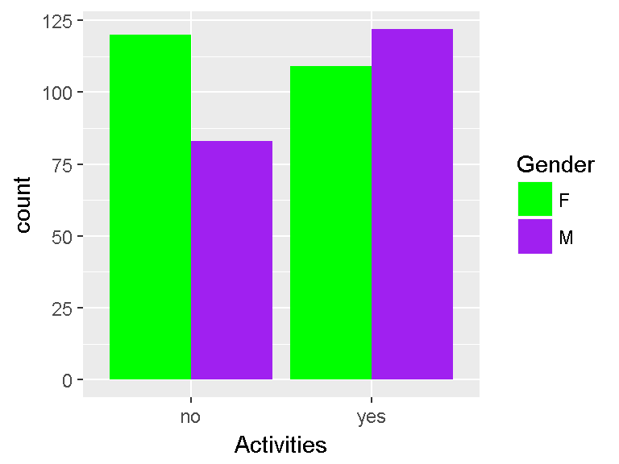

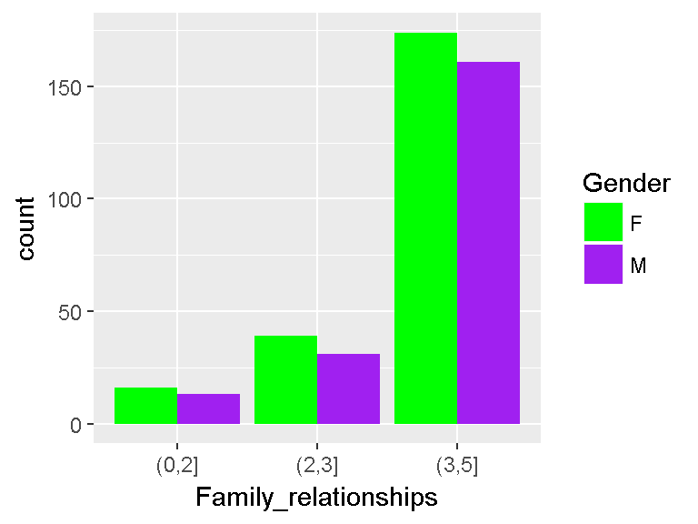

[7 more figures not shown]

```r
#lets plot
#density plots for numerical variables7
colNames <- names(dfalc)[2:ncol(dfalc)]
for(i in colNames){
    plt<-ggplot(dfalc, aes_string(x=i)) +
      geom_bar(aes(fill = Gender), position = "dodge", stat="count")+
      scale_fill_manual(values = c("green","purple"))
      print(plt)
}
```

The goal is to discover interesting relations among the variables.

The variables are visualized firstly by barplots stratified by gender. Thereafter, one crude variable summary as well as summary tables are created using three different strata: gender, performance group and alcohol use. ###

#### Overall summary

```r
library(settings)
reset(options)
options("scipen"=10, "digits"=2)
tab1<-CreateTableOne(vars=colnames(dfalc) ,data=dfalc,factorVars = colnames(dfalc[-19]))
summary(tab1)
```

```
##
##      ### Summary of continuous variables ###
##
## strata: Overall
##               n miss p.miss mean sd median p25 p75 min max skew kurt
## Final_Grade 434    0      0   11  3     12  10  14   1  18 -0.5  0.1
##
## =======================================================================================
##
##      ### Summary of categorical variables ###
##
## strata: Overall
##                   var   n miss p.miss     level freq percent cum.percent
##                Gender 434    0    0.0         F  229    52.8        52.8
##                                               M  205    47.2       100.0
##
##              Agegroup 434    0    0.0    (0,16]  213    49.1        49.1
##                                         (16,17]  112    25.8        74.9
##                                        (17,Inf]  109    25.1       100.0
##
##      Parents.together 434    0    0.0         A   40     9.2         9.2
##                                               T  394    90.8       100.0
##
##           Education_M 434    0    0.0    (-1,2]  182    41.9        41.9
##                                           (2,3]  109    25.1        67.1
##                                           (3,4]  143    32.9       100.0
##
##           Education_F 434    0    0.0    (-1,2]  218    50.2        50.2
##                                           (2,3]  112    25.8        76.0
##                                           (3,4]  104    24.0       100.0
##
##                 Job_M 434    0    0.0   at_home   60    13.8        13.8
##                                          health   35     8.1        21.9
##                                           other  168    38.7        60.6
##                                        services  103    23.7        84.3
##                                         teacher   68    15.7       100.0
##
##                 Job_F 434    0    0.0   at_home   16     3.7         3.7
##                                          health   17     3.9         7.6
##                                           other  248    57.1        64.7
```

[output cut: 31 more lines]

```
##        Class_failures 434    0    0.0         0  385    88.7        88.7
##                                               1   49    11.3       100.0
##
##          Absencegroup 434    0    0.0  (-Inf,1]  128    29.5        29.5
##                                           (1,6]  204    47.0        76.5
##                                        (6, Inf]  102    23.5       100.0
##
##      Performancegroup 434    0    0.0 (-Inf,10]  162    37.3        37.3
##                                         (10,12]  124    28.6        65.9
##                                         (12,14]   75    17.3        83.2
##                                       (14, Inf]   73    16.8       100.0
##
##          High_alcohol 434    0    0.0         0  268    61.8        61.8
##                                               1  166    38.2       100.0
##
```

```r
reset(options)
```

#### Summary stratified by **gender**

Data variable summary stratified by GENDER

|  | F | M | p | test |
| --- | --- | --- | --- | --- |
| n | 229 | 205 |  |  |
| Gender = M (%) | 0 ( 0.0) | 205 (100.0) | <0.001 |  |
| Agegroup (%) |  |  | 0.139 |  |
| (0,16] | 105 (45.9) | 108 ( 52.7) |  |  |
| (16,17] | 68 (29.7) | 44 ( 21.5) |  |  |
| (17,Inf] | 56 (24.5) | 53 ( 25.9) |  |  |
| Parents.together = T (%) | 207 (90.4) | 187 ( 91.2) | 0.896 |  |
| Education_M (%) |  |  | 0.023 |  |
| (-1,2] | 108 (47.2) | 74 ( 36.1) |  |  |
| (2,3] | 58 (25.3) | 51 ( 24.9) |  |  |
| (3,4] | 63 (27.5) | 80 ( 39.0) |  |  |
| Education_F (%) |  |  | 0.285 |  |
| (-1,2] | 121 (52.8) | 97 ( 47.3) |  |  |
| (2,3] | 60 (26.2) | 52 ( 25.4) |  |  |
| (3,4] | 48 (21.0) | 56 ( 27.3) |  |  |
| Job_M (%) |  |  | <0.001 |  |
| at_home | 44 (19.2) | 16 ( 7.8) |  |  |
| health | 20 ( 8.7) | 15 ( 7.3) |  |  |
| other | 94 (41.0) | 74 ( 36.1) |  |  |
| services | 51 (22.3) | 52 ( 25.4) |  |  |
| teacher | 20 ( 8.7) | 48 ( 23.4) |  |  |
| Job_F (%) |  |  | 0.195 |  |
| at_home | 11 ( 4.8) | 5 ( 2.4) |  |  |
| health | 11 ( 4.8) | 6 ( 2.9) |  |  |
| other | 131 (57.2) | 117 ( 57.1) |  |  |
| services | 63 (27.5) | 55 ( 26.8) |  |  |
| teacher | 13 ( 5.7) | 22 ( 10.7) |  |  |
| Guardian (%) |  |  | 0.540 |  |
| father | 50 (21.8) | 54 ( 26.3) |  |  |
| mother | 170 (74.2) | 144 ( 70.2) |  |  |
| other | 9 ( 3.9) | 7 ( 3.4) |  |  |
| Familial_support = yes (%) | 156 (68.1) | 109 ( 53.2) | 0.002 |  |
| Education_pos = yes (%) | 225 (98.3) | 188 ( 91.7) | 0.003 |  |
| In_relationship = yes (%) | 80 (34.9) | 56 ( 27.3) | 0.109 |  |
| Activities = yes (%) | 109 (47.6) | 122 ( 59.5) | 0.017 |  |
| Family_relationships (%) |  |  | 0.817 |  |
| (0,2] | 16 ( 7.0) | 13 ( 6.3) |  |  |
| (2,3] | 39 (17.0) | 31 ( 15.1) |  |  |
| (3,5] | 174 (76.0) | 161 ( 78.5) |  |  |
| Going_out (%) |  |  | 0.505 |  |
| (0,2] | 78 (34.1) | 61 ( 29.8) |  |  |
| (2,3] | 74 (32.3) | 65 ( 31.7) |  |  |
| (3,5] | 77 (33.6) | 79 ( 38.5) |  |  |
| Healthgroup (%) |  |  | 0.084 |  |
| (0,2] | 61 (26.6) | 39 ( 19.0) |  |  |
| (2,3] | 48 (21.0) | 38 ( 18.5) |  |  |
| (3,5] | 120 (52.4) | 128 ( 62.4) |  |  |
| Class_failures = 1 (%) | 22 ( 9.6) | 27 ( 13.2) | 0.308 |  |
| Absencegroup (%) |  |  | 0.936 |  |
| (-Inf,1] | 66 (28.8) | 62 ( 30.2) |  |  |
| (1,6] | 108 (47.2) | 96 ( 46.8) |  |  |
| (6, Inf] | 55 (24.0) | 47 ( 22.9) |  |  |
| Performancegroup (%) |  |  | 0.325 |  |
| (-Inf,10] | 87 (38.0) | 75 ( 36.6) |  |  |
| (10,12] | 72 (31.4) | 52 ( 25.4) |  |  |
| (12,14] | 34 (14.8) | 41 ( 20.0) |  |  |
| (14, Inf] | 36 (15.7) | 37 ( 18.0) |  |  |
| Final_Grade (mean (sd)) | 11.31 (3.18) | 11.53 (3.44) | 0.495 |  |
| High_alcohol = 1 (%) | 63 (27.5) | 103 ( 50.2) | <0.001 |  |

#### Summary stratified by **final grade**

Data variable summary stratified by FINAL GRADE

|  | (-Inf,10] | (10,12] | (12,14] | (14, Inf] | p | test |
| --- | --- | --- | --- | --- | --- | --- |
| n | 162 | 124 | 75 | 73 |  |  |
| Gender = M (%) | 75 ( 46.3) | 52 ( 41.9) | 41 ( 54.7) | 37 ( 50.7) | 0.325 |  |
| Agegroup (%) |  |  |  |  | 0.063 |  |
| (0,16] | 68 ( 42.0) | 62 ( 50.0) | 46 ( 61.3) | 37 ( 50.7) |  |  |
| (16,17] | 42 ( 25.9) | 34 ( 27.4) | 19 ( 25.3) | 17 ( 23.3) |  |  |
| (17,Inf] | 52 ( 32.1) | 28 ( 22.6) | 10 ( 13.3) | 19 ( 26.0) |  |  |
| Parents.together = T (%) | 150 ( 92.6) | 113 ( 91.1) | 68 ( 90.7) | 63 ( 86.3) | 0.493 |  |
| Education_M (%) |  |  |  |  | <0.001 |  |
| (-1,2] | 84 ( 51.9) | 58 ( 46.8) | 24 ( 32.0) | 16 ( 21.9) |  |  |
| (2,3] | 40 ( 24.7) | 33 ( 26.6) | 18 ( 24.0) | 18 ( 24.7) |  |  |
| (3,4] | 38 ( 23.5) | 33 ( 26.6) | 33 ( 44.0) | 39 ( 53.4) |  |  |
| Education_F (%) |  |  |  |  | 0.021 |  |
| (-1,2] | 94 ( 58.0) | 65 ( 52.4) | 32 ( 42.7) | 27 ( 37.0) |  |  |
| (2,3] | 39 ( 24.1) | 33 ( 26.6) | 21 ( 28.0) | 19 ( 26.0) |  |  |
| (3,4] | 29 ( 17.9) | 26 ( 21.0) | 22 ( 29.3) | 27 ( 37.0) |  |  |
| Job_M (%) |  |  |  |  | <0.001 |  |
| at_home | 32 ( 19.8) | 15 ( 12.1) | 7 ( 9.3) | 6 ( 8.2) |  |  |
| health | 7 ( 4.3) | 5 ( 4.0) | 15 ( 20.0) | 8 ( 11.0) |  |  |
| other | 64 ( 39.5) | 62 ( 50.0) | 22 ( 29.3) | 20 ( 27.4) |  |  |
| services | 38 ( 23.5) | 22 ( 17.7) | 21 ( 28.0) | 22 ( 30.1) |  |  |
| teacher | 21 ( 13.0) | 20 ( 16.1) | 10 ( 13.3) | 17 ( 23.3) |  |  |
| Job_F (%) |  |  |  |  | 0.008 |  |
| at_home | 6 ( 3.7) | 5 ( 4.0) | 0 ( 0.0) | 5 ( 6.8) |  |  |
| health | 6 ( 3.7) | 3 ( 2.4) | 4 ( 5.3) | 4 ( 5.5) |  |  |
| other | 94 ( 58.0) | 82 ( 66.1) | 41 ( 54.7) | 31 ( 42.5) |  |  |
| services | 46 ( 28.4) | 29 ( 23.4) | 24 ( 32.0) | 19 ( 26.0) |  |  |
| teacher | 10 ( 6.2) | 5 ( 4.0) | 6 ( 8.0) | 14 ( 19.2) |  |  |
| Guardian (%) |  |  |  |  | 0.111 |  |
| father | 41 ( 25.3) | 24 ( 19.4) | 20 ( 26.7) | 19 ( 26.0) |  |  |
| mother | 110 ( 67.9) | 97 ( 78.2) | 55 ( 73.3) | 52 ( 71.2) |  |  |
| other | 11 ( 6.8) | 3 ( 2.4) | 0 ( 0.0) | 2 ( 2.7) |  |  |
| Familial_support = yes (%) | 103 ( 63.6) | 77 ( 62.1) | 40 ( 53.3) | 45 ( 61.6) | 0.497 |  |
| Education_pos = yes (%) | 142 ( 87.7) | 123 ( 99.2) | 75 (100.0) | 73 (100.0) | <0.001 |  |
| In_relationship = yes (%) | 52 ( 32.1) | 42 ( 33.9) | 22 ( 29.3) | 20 ( 27.4) | 0.782 |  |
| Activities = yes (%) | 78 ( 48.1) | 69 ( 55.6) | 41 ( 54.7) | 43 ( 58.9) | 0.395 |  |
| Family_relationships (%) |  |  |  |  | 0.361 |  |
| (0,2] | 11 ( 6.8) | 6 ( 4.8) | 9 ( 12.0) | 3 ( 4.1) |  |  |
| (2,3] | 29 ( 17.9) | 22 ( 17.7) | 10 ( 13.3) | 9 ( 12.3) |  |  |
| (3,5] | 122 ( 75.3) | 96 ( 77.4) | 56 ( 74.7) | 61 ( 83.6) |  |  |
| Going_out (%) |  |  |  |  | 0.307 |  |
| (0,2] | 48 ( 29.6) | 41 ( 33.1) | 24 ( 32.0) | 26 ( 35.6) |  |  |
| (2,3] | 46 ( 28.4) | 37 ( 29.8) | 29 ( 38.7) | 27 ( 37.0) |  |  |
| (3,5] | 68 ( 42.0) | 46 ( 37.1) | 22 ( 29.3) | 20 ( 27.4) |  |  |
| Healthgroup (%) |  |  |  |  | 0.016 |  |
| (0,2] | 30 ( 18.5) | 24 ( 19.4) | 20 ( 26.7) | 26 ( 35.6) |  |  |
| (2,3] | 37 ( 22.8) | 29 ( 23.4) | 7 ( 9.3) | 13 ( 17.8) |  |  |
| (3,5] | 95 ( 58.6) | 71 ( 57.3) | 48 ( 64.0) | 34 ( 46.6) |  |  |
| Class_failures = 1 (%) | 40 ( 24.7) | 7 ( 5.6) | 0 ( 0.0) | 2 ( 2.7) | <0.001 |  |
| Absencegroup (%) |  |  |  |  | 0.212 |  |
| (-Inf,1] | 44 ( 27.2) | 36 ( 29.0) | 21 ( 28.0) | 27 ( 37.0) |  |  |
| (1,6] | 72 ( 44.4) | 56 ( 45.2) | 41 ( 54.7) | 35 ( 47.9) |  |  |
| (6, Inf] | 46 ( 28.4) | 32 ( 25.8) | 13 ( 17.3) | 11 ( 15.1) |  |  |
| Performancegroup (%) |  |  |  |  | <0.001 |  |
| (-Inf,10] | 162 (100.0) | 0 ( 0.0) | 0 ( 0.0) | 0 ( 0.0) |  |  |
| (10,12] | 0 ( 0.0) | 124 (100.0) | 0 ( 0.0) | 0 ( 0.0) |  |  |
| (12,14] | 0 ( 0.0) | 0 ( 0.0) | 75 (100.0) | 0 ( 0.0) |  |  |
| (14, Inf] | 0 ( 0.0) | 0 ( 0.0) | 0 ( 0.0) | 73 (100.0) |  |  |
| Final_Grade (mean (sd)) | 8.03 (2.25) | 11.77 (0.42) | 13.60 (0.49) | 16.08 (0.85) | <0.001 |  |
| High_alcohol = 1 (%) | 66 ( 40.7) | 56 ( 45.2) | 23 ( 30.7) | 21 ( 28.8) | 0.057 |  |

#### Summary stratified by **alcohol consumption**

Data variable summary stratified by ALCOHOL CONSUMPTION

|  | 0 | 1 | p | test |
| --- | --- | --- | --- | --- |
| n | 268 | 166 |  |  |
| Gender = M (%) | 102 (38.1) | 103 ( 62.0) | <0.001 |  |
| Agegroup (%) |  |  | 0.024 |  |
| (0,16] | 145 (54.1) | 68 ( 41.0) |  |  |
| (16,17] | 60 (22.4) | 52 ( 31.3) |  |  |
| (17,Inf] | 63 (23.5) | 46 ( 27.7) |  |  |
| Parents.together = T (%) | 242 (90.3) | 152 ( 91.6) | 0.785 |  |
| Education_M (%) |  |  | 0.049 |  |
| (-1,2] | 123 (45.9) | 59 ( 35.5) |  |  |
| (2,3] | 58 (21.6) | 51 ( 30.7) |  |  |
| (3,4] | 87 (32.5) | 56 ( 33.7) |  |  |
| Education_F (%) |  |  | 0.577 |  |
| (-1,2] | 139 (51.9) | 79 ( 47.6) |  |  |
| (2,3] | 69 (25.7) | 43 ( 25.9) |  |  |
| (3,4] | 60 (22.4) | 44 ( 26.5) |  |  |
| Job_M (%) |  |  | 0.458 |  |
| at_home | 38 (14.2) | 22 ( 13.3) |  |  |
| health | 18 ( 6.7) | 17 ( 10.2) |  |  |
| other | 111 (41.4) | 57 ( 34.3) |  |  |
| services | 62 (23.1) | 41 ( 24.7) |  |  |
| teacher | 39 (14.6) | 29 ( 17.5) |  |  |
| Job_F (%) |  |  | 0.062 |  |
| at_home | 14 ( 5.2) | 2 ( 1.2) |  |  |
| health | 13 ( 4.9) | 4 ( 2.4) |  |  |
| other | 152 (56.7) | 96 ( 57.8) |  |  |
| services | 65 (24.3) | 53 ( 31.9) |  |  |
| teacher | 24 ( 9.0) | 11 ( 6.6) |  |  |
| Guardian (%) |  |  | 0.570 |  |
| father | 63 (23.5) | 41 ( 24.7) |  |  |
| mother | 197 (73.5) | 117 ( 70.5) |  |  |
| other | 8 ( 3.0) | 8 ( 4.8) |  |  |
| Familial_support = yes (%) | 168 (62.7) | 97 ( 58.4) | 0.434 |  |
| Education_pos = yes (%) | 258 (96.3) | 155 ( 93.4) | 0.256 |  |
| In_relationship = yes (%) | 84 (31.3) | 52 ( 31.3) | 1.000 |  |
| Activities = yes (%) | 146 (54.5) | 85 ( 51.2) | 0.572 |  |
| Family_relationships (%) |  |  | 0.052 |  |
| (0,2] | 16 ( 6.0) | 13 ( 7.8) |  |  |
| (2,3] | 35 (13.1) | 35 ( 21.1) |  |  |
| (3,5] | 217 (81.0) | 118 ( 71.1) |  |  |
| Going_out (%) |  |  | <0.001 |  |
| (0,2] | 112 (41.8) | 27 ( 16.3) |  |  |
| (2,3] | 96 (35.8) | 43 ( 25.9) |  |  |
| (3,5] | 60 (22.4) | 96 ( 57.8) |  |  |
| Healthgroup (%) |  |  | 0.333 |  |
| (0,2] | 59 (22.0) | 41 ( 24.7) |  |  |
| (2,3] | 59 (22.0) | 27 ( 16.3) |  |  |
| (3,5] | 150 (56.0) | 98 ( 59.0) |  |  |
| Class_failures = 1 (%) | 21 ( 7.8) | 28 ( 16.9) | 0.006 |  |
| Absencegroup (%) |  |  | <0.001 |  |
| (-Inf,1] | 88 (32.8) | 40 ( 24.1) |  |  |
| (1,6] | 134 (50.0) | 70 ( 42.2) |  |  |
| (6, Inf] | 46 (17.2) | 56 ( 33.7) |  |  |
| Performancegroup (%) |  |  | 0.057 |  |
| (-Inf,10] | 96 (35.8) | 66 ( 39.8) |  |  |
| (10,12] | 68 (25.4) | 56 ( 33.7) |  |  |
| (12,14] | 52 (19.4) | 23 ( 13.9) |  |  |
| (14, Inf] | 52 (19.4) | 21 ( 12.7) |  |  |
| Final_Grade (mean (sd)) | 11.60 (3.43) | 11.11 (3.08) | 0.133 |  |
| High_alcohol = 1 (%) | 0 ( 0.0) | 166 (100.0) | <0.001 |  |

### Multiple correspondence analysis

#### Methodology

Simple form of analysing categorical data is cross-tabulation. Correspondence analysis is also a multivariate descriptive data analytic technique and can be used in dimensionality reducation. Furthermore, the graphical interpretation of the data could be useful tool in an exploratory research and the reduction of the level of the associations between the investigated parameters. Correspondence analysis is a generalization of principal component approach for normal and contingency table data.

Multiple correspondence analysis (MCA) is an extension of correspondence analysis and allows to investigate the pattern of relationships of several categorical dependent variables. Applying multiple correspondence analysis helps to reduce the interaction parameters. Using the results of a MCA, it is possible to describe the structure of all the categorical variables included. The computational graphical representations covers basically every bit of information in the data by mapping each variable/individual of analysis as a point in a low-dimensional space.

To encompass, MCA has several features that distinguish it from other techniques of data analysis. It simplifies large and complex data and provides a detailed description of practically every bit of information in the data, yielding a simple, yet exhaustive scrutiny of relationships occuring by multiple pair wise comparisons. Graphically, dual displays are produced to facilitate interpretation.

Basically, the first step is that a crosstabulated frequency table is standardized to yield relative frequencies across the cells to sum up to 1.0. The aim of a MCA analysis is to represent the entries in the table of relative frequencies in terms of the distances between individual rows and/or columns in a low-dimensional space.

### MCA

```r
res.mca = MCA(dfalc,quanti.sup=19, graph = FALSE)
#Investigate(res.mca)
#res.shiny=MCAshiny(dfalc)
```

MCA() function that come in the package “FactoMineR” by Francois Husson, Julie Josse, Sebastien Le, and Jeremy Mazet. Additionally, package “factoextra” is used.

#### Multiple Correspondence Analysis

The output of the MCA() function is a list including :

```r
res_mca <- MCA(dfalc, quanti.sup=19,graph = FALSE)
print(res_mca)
```

```
## **Results of the Multiple Correspondence Analysis (MCA)**
## The analysis was performed on 434 individuals, described by 20 variables
## *The results are available in the following objects:
##
##    name
## 1  "$eig"
## 2  "$var"
## 3  "$var$coord"
## 4  "$var$cos2"
## 5  "$var$contrib"
## 6  "$var$v.test"
## 7  "$ind"
## 8  "$ind$coord"
## 9  "$ind$cos2"
## 10 "$ind$contrib"
```

[output cut: 21 more lines]

```r
summary(res_mca, nbelements = Inf, ncp = 2, file = "summary_mca.xls")
```

For the variables a correlation ratio (squared) between it and each dimension is given (eta<sup>^2</sup>) enabling the plotting of the variables.

```r
summary(res_mca)
```

```
##
## Call:
## MCA(X = dfalc, quanti.sup = 19, graph = FALSE)
##
##
## Eigenvalues
##                        Dim.1   Dim.2   Dim.3   Dim.4   Dim.5   Dim.6
## Variance               0.151   0.104   0.089   0.081   0.079   0.075
## % of var.              8.207   5.638   4.829   4.389   4.310   4.075
## Cumulative % of var.   8.207  13.845  18.674  23.063  27.374  31.449
##                        Dim.7   Dim.8   Dim.9  Dim.10  Dim.11  Dim.12
## Variance               0.074   0.069   0.066   0.065   0.061   0.059
## % of var.              4.036   3.763   3.583   3.543   3.319   3.197
## Cumulative % of var.  35.486  39.248  42.831  46.373  49.692  52.889
##                       Dim.13  Dim.14  Dim.15  Dim.16  Dim.17  Dim.18
## Variance               0.057   0.055   0.055   0.051   0.048   0.048
## % of var.              3.083   3.005   2.966   2.784   2.622   2.605
## Cumulative % of var.  55.972  58.977  61.943  64.728  67.350  69.954
##                       Dim.19  Dim.20  Dim.21  Dim.22  Dim.23  Dim.24
## Variance               0.047   0.044   0.043   0.041   0.040   0.039
## % of var.              2.528   2.378   2.313   2.226   2.171   2.138
## Cumulative % of var.  72.483  74.861  77.173  79.399  81.570  83.708
##                       Dim.25  Dim.26  Dim.27  Dim.28  Dim.29  Dim.30
## Variance               0.038   0.035   0.034   0.032   0.030   0.028
## % of var.              2.049   1.881   1.858   1.756   1.630   1.518
## Cumulative % of var.  85.757  87.638  89.496  91.253  92.882  94.400
##                       Dim.31  Dim.32  Dim.33  Dim.34  Dim.35
## Variance               0.027   0.023   0.023   0.020   0.011
## % of var.              1.472   1.237   1.222   1.094   0.575
## Cumulative % of var.  95.873  97.110  98.332  99.425 100.000
##
## Individuals (the 10 first)
##                       Dim.1    ctr   cos2    Dim.2    ctr   cos2    Dim.3
## 1                  |  0.284  0.123  0.031 |  0.208  0.096  0.016 |  0.532
## 2                  | -0.481  0.352  0.153 | -0.391  0.339  0.101 |  0.434
## 3                  | -0.458  0.320  0.145 | -0.239  0.127  0.040 |  0.346
## 4                  | -0.623  0.591  0.201 |  0.065  0.009  0.002 |  0.253
## 5                  |  0.298  0.136  0.043 | -0.393  0.343  0.075 |  0.148
## 6                  | -0.098  0.015  0.008 | -0.451  0.451  0.166 | -0.454
## 7                  | -0.136  0.028  0.016 | -0.330  0.242  0.092 | -0.360
```

[output cut: 40 more lines]

```
##                      Dim.1 Dim.2 Dim.3
## Gender             | 0.036 0.138 0.005 |
## Agegroup           | 0.069 0.129 0.017 |
## Parents.together   | 0.011 0.002 0.024 |
## Education_M        | 0.700 0.033 0.397 |
## Education_F        | 0.596 0.036 0.221 |
## Job_M              | 0.551 0.055 0.286 |
## Job_F              | 0.358 0.056 0.274 |
## Guardian           | 0.026 0.062 0.012 |
## Familial_support   | 0.037 0.012 0.000 |
## Education_pos      | 0.053 0.225 0.091 |
##
## Supplementary continuous variable
##                      Dim.1   Dim.2   Dim.3
## Final_Grade        |  0.43 | -0.39 | -0.16 |
```

The dimdesc function aims to help to interpret the dimensions. It allows to see which variables the axes are the most linked to, i.e. which categories describe the best each axis.

```r
dimdesc(res_mca,axes=1:2,proba=0.05)
```

```
## $`Dim 1`
## $`Dim 1`$quanti
##             correlation p.value
## Final_Grade        0.43 3.2e-21
##
## $`Dim 1`$quali
##                     R2  p.value
## Education_M      0.700 2.5e-113
## Education_F      0.596  1.2e-85
## Job_M            0.551  3.8e-73
## Job_F            0.358  3.7e-40
## Performancegroup 0.207  1.7e-21
## Class_failures   0.117  2.1e-13
## Agegroup         0.069  2.2e-07
## Activities       0.059  3.2e-07
## Education_pos    0.053  1.2e-06
## Familial_support 0.037  5.8e-05
## Gender           0.036  7.4e-05
## Healthgroup      0.042  1.0e-04
## Guardian         0.026  3.7e-03
## Parents.together 0.011  3.3e-02
##
## $`Dim 1`$category
##                      Estimate p.value
## Education_M_(3,4]       0.418 3.6e-96
## Education_F_(3,4]       0.381 8.4e-62
## Job_M_teacher           0.456 1.2e-42
## Job_F_teacher           0.486 4.9e-30
## Class_failures_0        0.211 2.1e-13
## (14, Inf]               0.227 1.1e-12
## (0,16]                  0.136 3.2e-08
## Job_M_health            0.249 1.3e-07
## Activities_yes          0.094 3.2e-07
## Education_pos_yes       0.209 1.2e-06
## Job_F_health            0.260 1.3e-06
## (12,14]                 0.121 7.2e-06
## Familial_support_yes    0.076 5.8e-05
## M                       0.074 7.4e-05
## Healthgroup_(0,2]       0.099 1.5e-02
## A                       0.069 3.3e-02
```

[output cut: 69 more lines]

```
## Family_relationships_(3,5]  -0.0720 2.1e-02
## Guardian_father             -0.1737 1.2e-02
## (14, Inf]                   -0.0602 4.8e-03
## (10,12]                     -0.0363 2.8e-03
## Healthgroup_(2,3]           -0.0851 6.6e-04
## Education_M_(-1,2]          -0.0794 1.3e-04
## Going_out_(2,3]             -0.0822 4.6e-05
## (-Inf,1]                    -0.1177 4.1e-05
## (12,14]                     -0.1059 2.2e-05
## (0,16]                      -0.1205 3.7e-09
## Going_out_(0,2]             -0.1501 3.8e-13
## F                           -0.1199 1.2e-15
## Education_pos_yes           -0.3561 1.0e-25
## Class_failures_0            -0.2556 4.5e-29
## High_alcohol_0              -0.1994 4.9e-44
```

##### Scree plot

To visualize the percentage of inertia explained by each MCA dimensions:

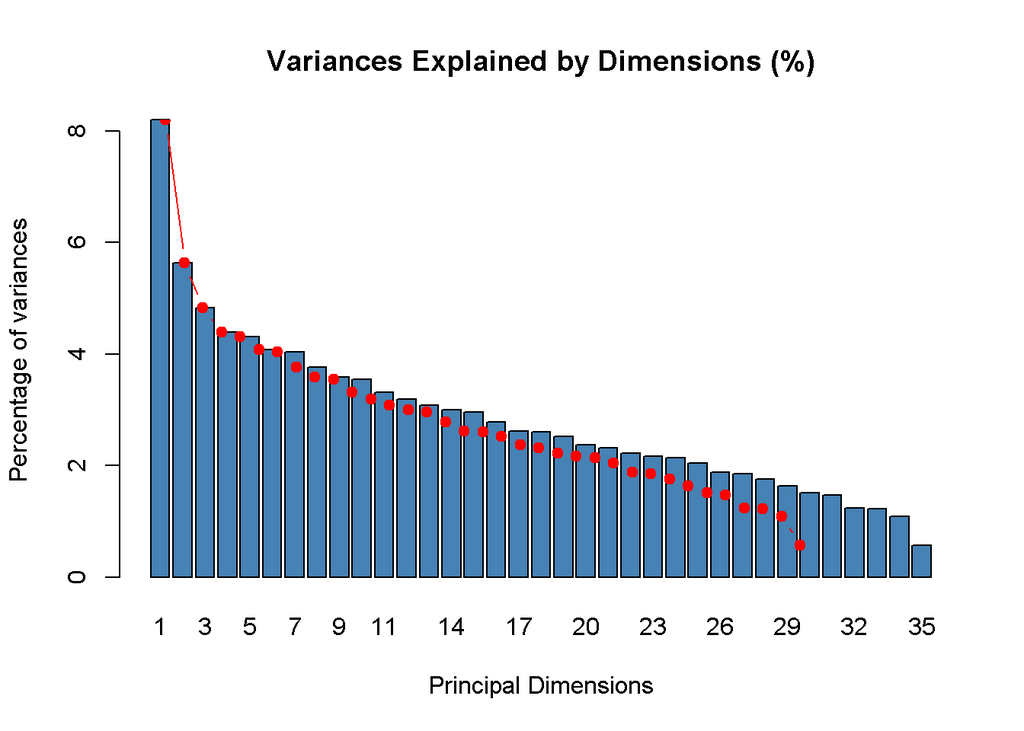

```r
eig.val <- res_mca$eig
barplot(eig.val[, 2],
        names.arg = 1:nrow(eig.val),
        main = "Variances Explained by Dimensions (%)",
        xlab = "Principal Dimensions",
        ylab = "Percentage of variances",
        col ="steelblue")
# Add connected line segments to the plot
lines(x = 1:nrow(eig.val), eig.val[, 2],
      type = "b", pch = 19, col = "red")
```

Eigenvalues can be used to determine the number of axes to retain. There is no “rule of thumb” to choose the number of dimensions to keep for the data interpretation. It depends on the research question and the researcher’s need. For example, if you are satisfied with 80% of the total variances explained then use the number of dimensions necessary to achieve that.

The inertia of the first and second dimensions suggest the number of dimensions that should be studied. The first two express 14% of the total dataset variance meaning that 14% of the individuals or variables total variability is explained by the plane. This is disappointedly a very small percentage.

The proportion of variances retained by the different dimensions (axes) can be extracted using the function get_eigenvalue() as follow:

```r
eig.val <- get_eigenvalue(res_mca)
head(eig.val,n=10)
```

```
##        eigenvalue variance.percent cumulative.variance.percent
## Dim.1       0.151              8.2                         8.2
## Dim.2       0.104              5.6                        13.8
## Dim.3       0.089              4.8                        18.7
## Dim.4       0.081              4.4                        23.1
## Dim.5       0.079              4.3                        27.4
## Dim.6       0.075              4.1                        31.4
## Dim.7       0.074              4.0                        35.5
## Dim.8       0.069              3.8                        39.2
## Dim.9       0.066              3.6                        42.8
## Dim.10      0.065              3.5                        46.4
```

##### Description of the first plane

To further clarify the MCA results graphical representation is used. Firstly, there is biplot showing the global pattern within the data. Observations are represented by blue points and variables by red triangles and labels. The distance between any observation points or variable points gives a measure of their similarity (or dissimilarity). Similar types of individuals are close on the map, as well as similar kinds of variables. The function fviz_mca_biplot() [factoextra package] is used to draw the biplot of individuals and variable categories:

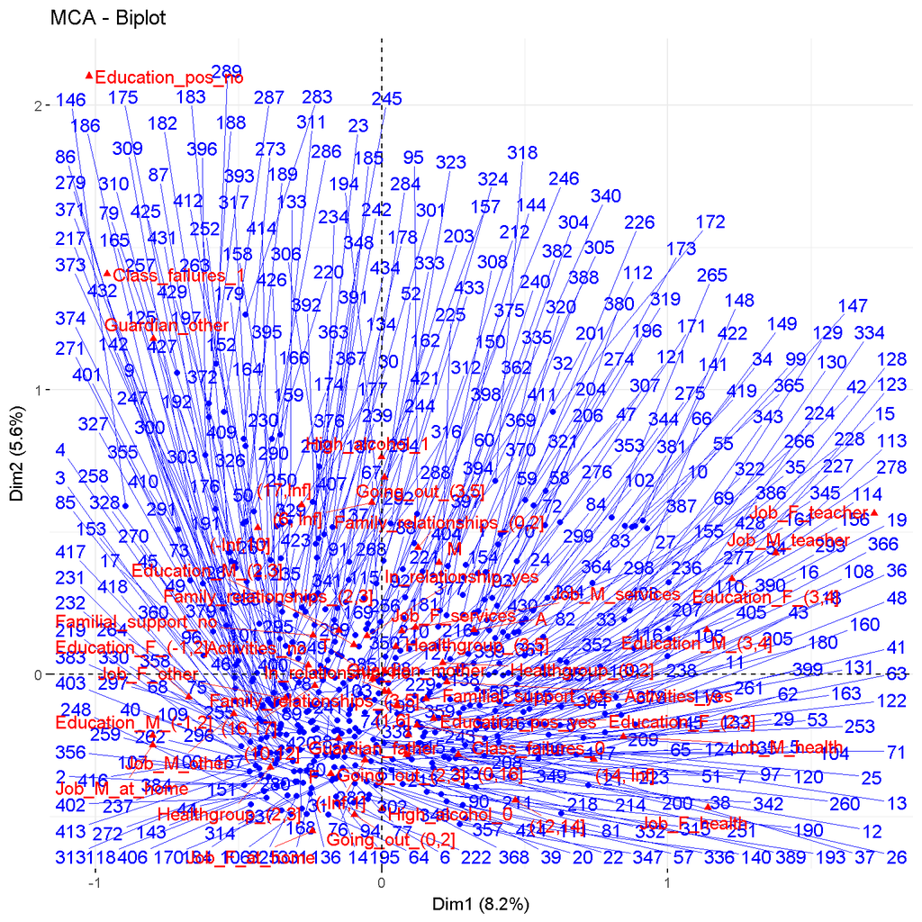

```r
fviz_mca_biplot(res_mca,
               repel = TRUE, # Avoid text overlapping (slow if many point)
               ggtheme = theme_minimal())
```

##### Biplots

Next, a plot is created to visualize the correlation between variables and MCA principal dimensions:

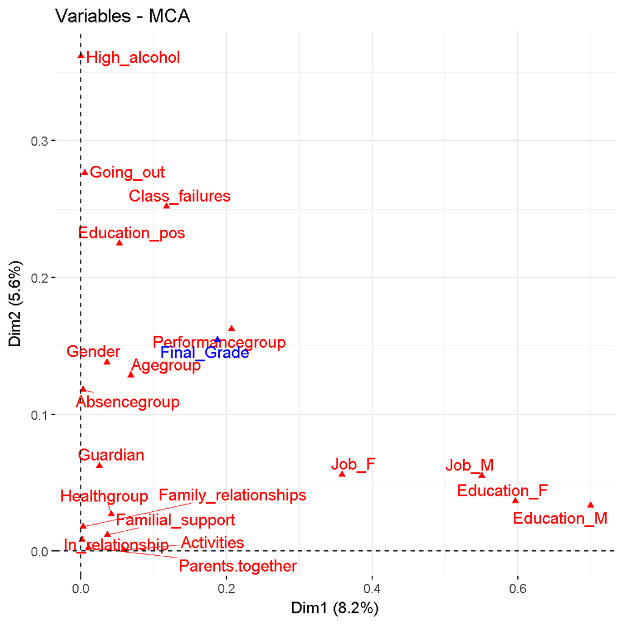

```r
fviz_mca_var(res_mca, choice = "mca.cor",
            repel = TRUE, # Avoid text overlapping (slow)
            ggtheme = theme_minimal())
```

The plot should help to identify variables that are the most correlated with each dimension. The squared correlations between variables and the dimensions are used as coordinates.

The function get_mca_var() [in factoextra] is used to extract the results for variable categories. This function returns a list containing the coordinates, the cos2 and the contribution of variable categories:

var$coord: coordinates of variables to create a scatter plot var$cos2: represents the quality of the representation for variables on the factor map. var$contrib: contains the contributions (in percentage) of the variables to the definition of the dimensions.

```r
var <- get_mca_var(res_mca)
var
```

```
## Multiple Correspondence Analysis Results for variables
##  ===================================================
##   Name       Description
## 1 "$coord"   "Coordinates for categories"
## 2 "$cos2"    "Cos2 for categories"
## 3 "$contrib" "contributions of categories"
```

To visualize the correlation between variables and MCA principal dimensions, type this:

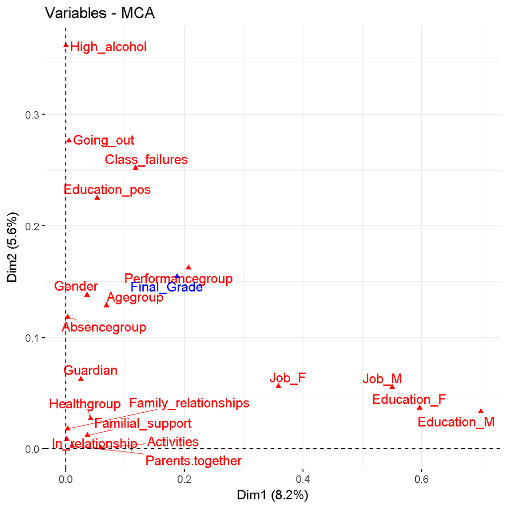

```r
fviz_mca_var(res.mca, choice = "mca.cor",
            repel = TRUE, # Avoid text overlapping (slow)
            ggtheme = theme_minimal())
```

The plot above helps to identify variables that are the most correlated with each dimension. The squared correlations between variables and the dimensions are used as coordinates.

Use the function fviz_mca_var() [in factoextra] to visualize only variable categories:

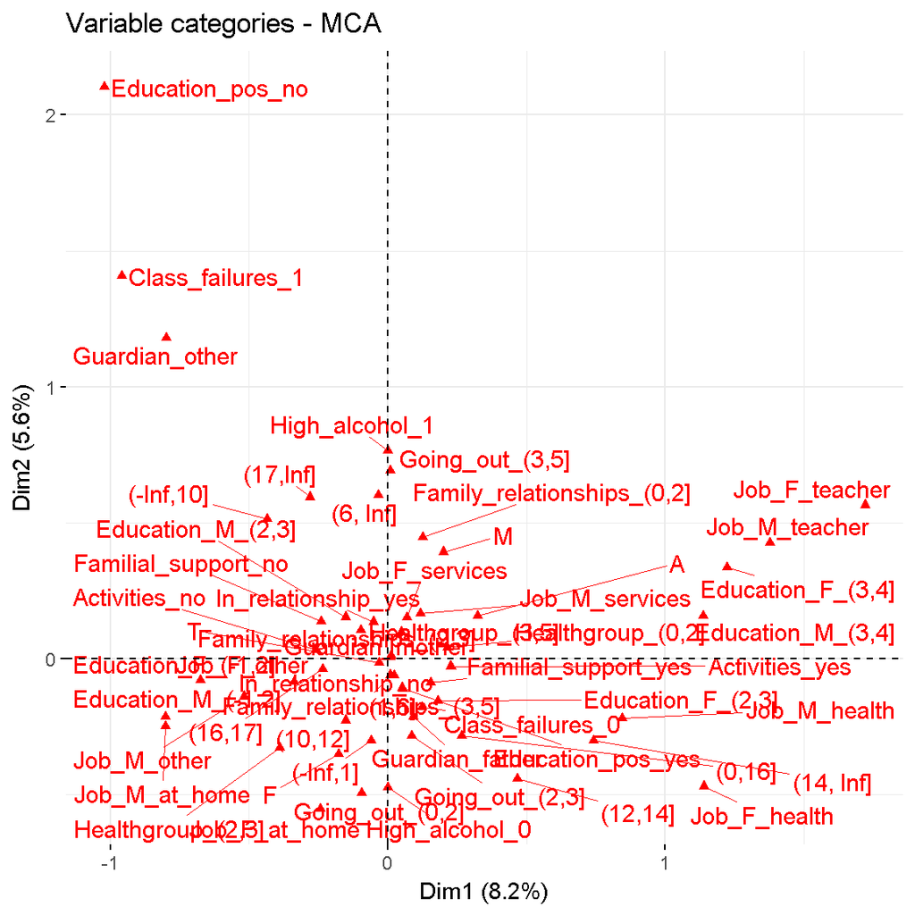

```r
fviz_mca_var(res_mca,
             repel = TRUE, # Avoid text overlapping (slow)
             ggtheme = theme_minimal())
```

It’s possible to change the color and the shape of the variable points using the arguments col.var and shape.var as follow:

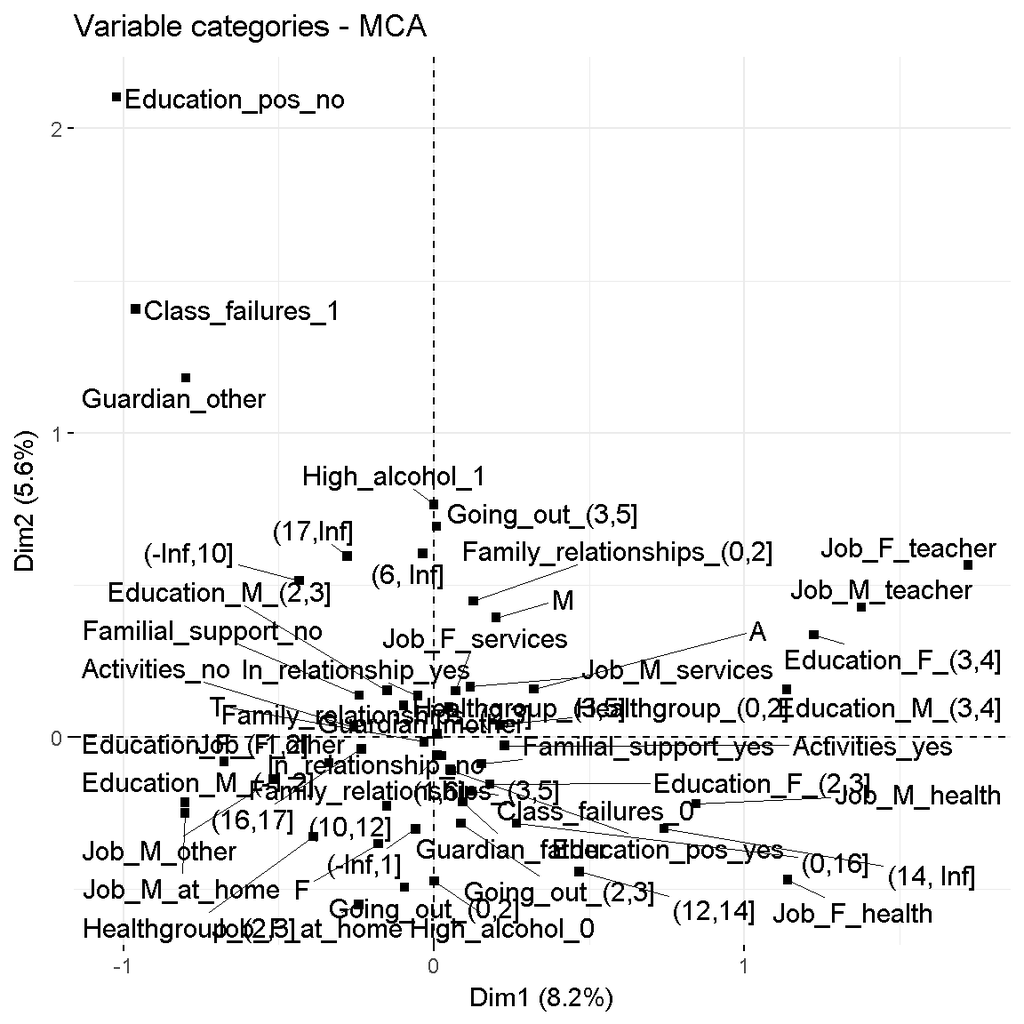

```r
fviz_mca_var(res_mca, col.var="black", shape.var = 15,
             repel = TRUE)
```

Variable categories with a similar profile are grouped together. Negatively correlated variable categories are positioned on opposite sides of the plot origin (opposed quadrants). The distance between category points and the origin measures the quality of the variable category on the factor map. Category points that are away from the origin are well represented on the factor map.

If a variable category is well represented by two dimensions, the sum of the cos2 is closed to one. For some of the row items, more than 2 dimensions are required to perfectly represent the data.

It’s possible to color variable categories by their cos2 values using the argument col.var = “cos2”. This produces a gradient colors, which can be customized using the argument gradient.cols. For instance, gradient.cols = c(“white”, “blue”, “red”) means that:

variable categories with low cos2 values will be colored in “white” variable categories with mid cos2 values will be colored in “blue” variable categories with high cos2 values will be colored in “red”

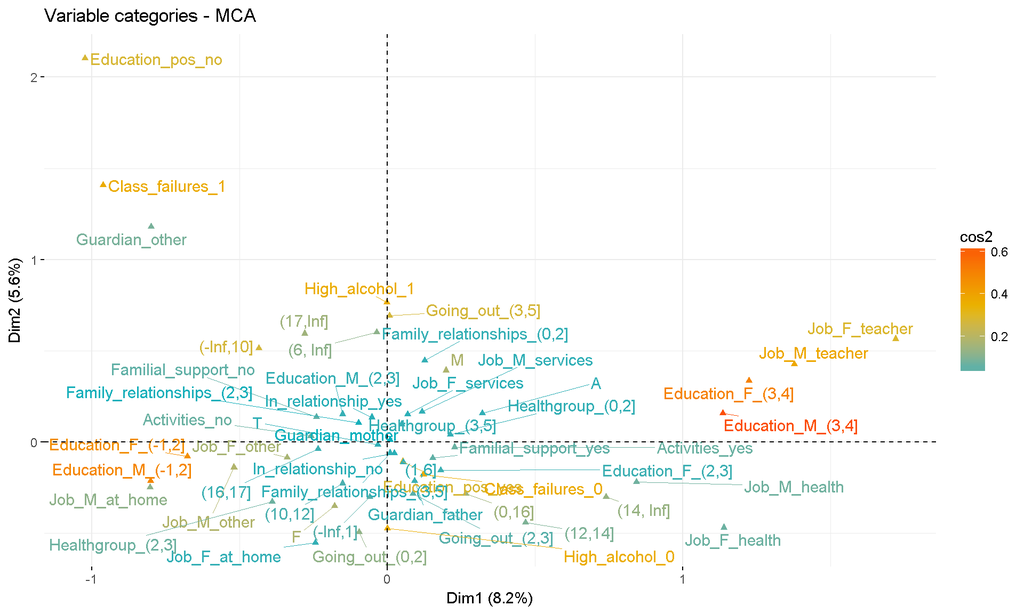

```r
# Color by cos2 values: quality on the factor map
fviz_mca_var(res_mca, col.var = "cos2",
             gradient.cols = c("#00AFBB", "#E7B800", "#FC4E07"),
             repel = TRUE, # Avoid text overlapping
             ggtheme = theme_minimal())
```

And finally, as is described in the exercise instructions: “The typical graphs show the original classes of the discrete variables on the same”map“, making it possible to reveal connections (correspondences) between different things that would be quite impossible to see from the corresponding cross tables (too many numbers!).”

Note that, it’s also possible to change the transparency of the variable categories according to their cos2 values using the option alpha.var = “cos2”. For example, type this:

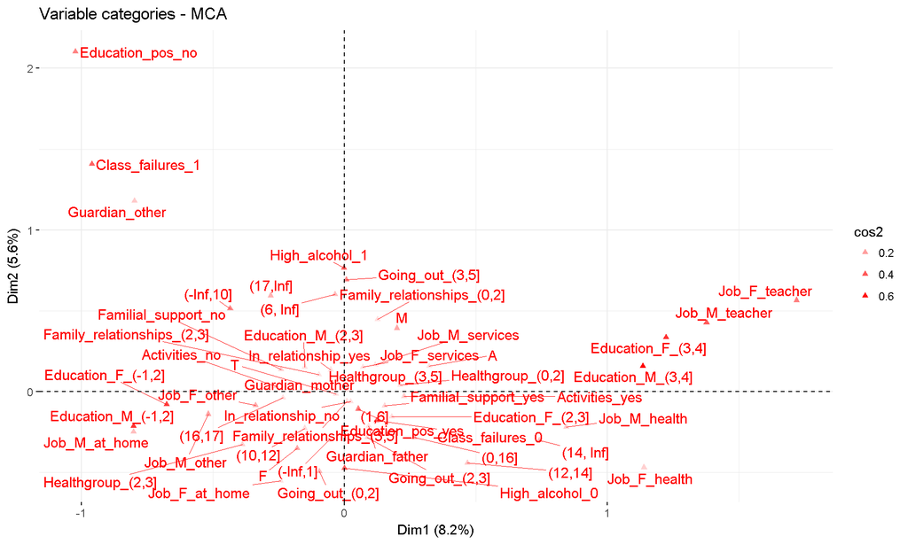

```r
# Change the transparency by cos2 values
fviz_mca_var(res_mca, alpha.var="cos2",
             repel = TRUE,
             ggtheme = theme_minimal(),selectMod="cos2 10")
```

You can visualize the cos2 of row categories on all the dimensions using the corrplot package:

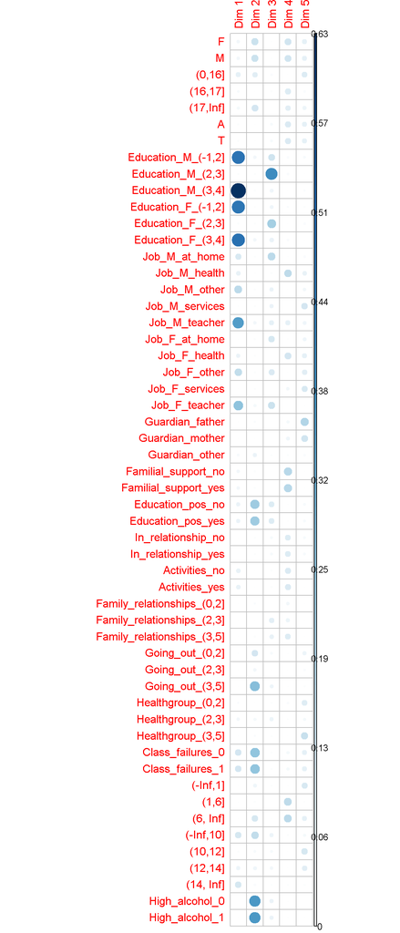

```r
library("corrplot")
corrplot(var$cos2, is.corr=FALSE)
```

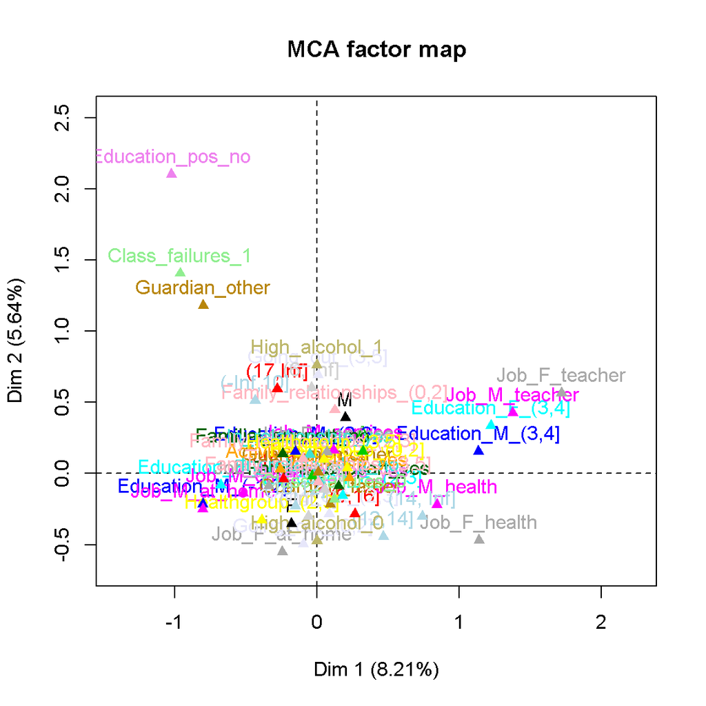

```r
plot(res_mca, invisible=c("ind"), habillage = "quali")
```

It’s also possible to create a bar plot of variable cos2 using the function fviz_cos2()[in factoextra]:

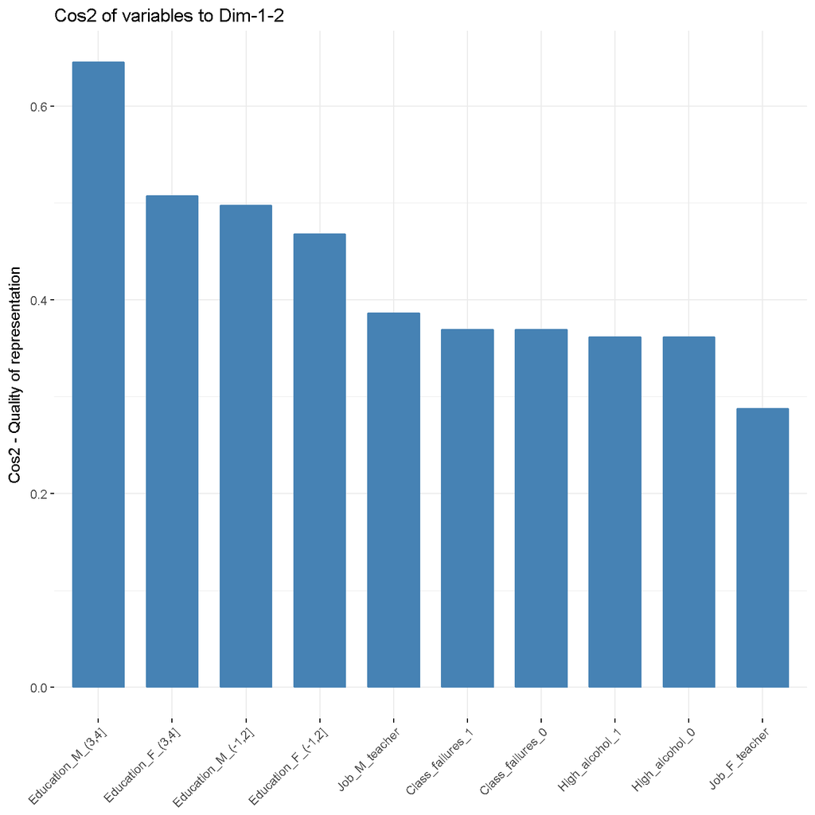

```r
# Cos2 of variable categories on Dim.1 and Dim.2
fviz_cos2(res_mca, n=10,choice = "var", axes = 1:2,top=10)
```

The function fviz_contrib() [factoextra package] can be used to draw a bar plot of the contribution of variable categories. The R code below shows the top 15 variable categories contributing to the dimensions:

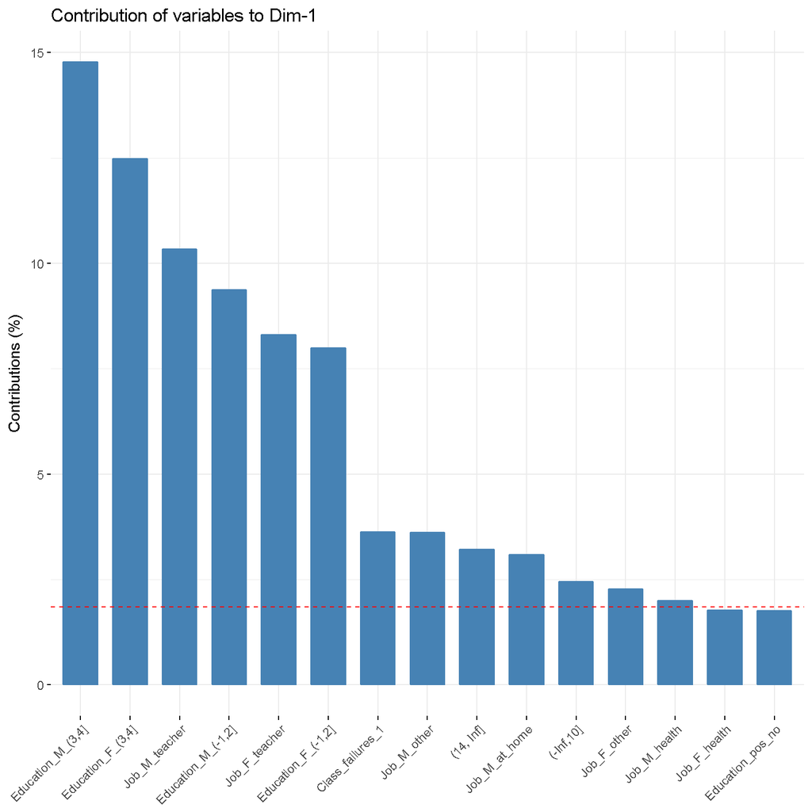

```r
# Contributions of rows to dimension 1
fviz_contrib(res_mca, choice = "var", axes = 1, top = 15)
```